# Assignment 2 for Statistical Computing and Empirical Methods: Reproducible Data Science

Henry Reeve

# Introduction

This document describes your second assignment for Statistical Computing and Empirical Methods (Unit EMATM0061) on the MSc in Data Science. Before starting the assignment it is recommend that you first watch video lecture 2 entitled “Reproducible Data Analysis”. The goal of this assignment is for you to set up a GitHub account, install Git to your local machine, set up your first R project and write your first R markdown notebook. A fantastic resource for git and R integration is the website https://happygitwithr.com/ created by the Jenny Bryan, a renowned Data Scientist and expert in R. If you have any issues with steps 1 through 5 we recommend you go to this website for more detailed instructions.

# 1 Register for a Git account

Go to https://github.com/ and sign up for a free GitHub account. Its a good idea to choose something sensible and simple here as you may well want to share your github profile with future employers. Be careful to choose a secure password. You can also gain access to more tools as student via GitHub education https://education.github.com/.

# 2 Install Git

Install git on your own machine. The way to do this depends upon your operating system:

- **Windows:** Go to https://gitforwindows.org/, click the download button and then install. Choose “Git from the command line and also from 3rd-party software” when asked about “Adjusting your PATH environment”.
- **Mac OSX:** At your command line type `xcode-select --install`.
- **Ubuntu or Debian Linux:** At your command line type `sudo apt-get install git`.
- **Fedora or RedHat Linux:** At your command line type `sudo yum install git`.

# 3 Connect RStudio to git

There are several ways to do this. The most straightforward appears to be with the “usethis” R package. Go to RStudio. You can connect to git by performing the following steps within your R console:

```
install.packages("usethis") # Install the "usethis" R package
library(usethis) # Load the "usethis" R library
use_git_config(user.name = "Bob Smith", user.email = "bob@example.org") # Set git profile info
```

The first step installs the “usethis” R package. The second step loads the “usethis” R library. You may be prompted to install RTools at this stage. If so follow the links provided by RStudio. The third step sets your git profile information. The user name you enter should be the same as the username you used to set up your git profile. Similarly, the email needs to be the same email address as you used to set up your git profile.

# 4 Create an R project with version control

Go to https://github.com/ within your web browser and log into your git account. Create a new repository by clicking the green “New” button. Next:

1. Give your repository a name eg. “firstRProject”.
2. Give your repository a description eg. “This is a repo for an R project”.
3. Check the box which says “Add a README file”.
4. Always be mindful over whether your repo is public or private.
5. Click the green “Create repository” button.

You have now created a git repository. Next click the green “Code” button and copy the url provided. This is the repository url.

Next go back to RStudio. Then go to:

```
File -> New Project... -> Version Control -> Git
```

1. Below “Repository URL:” Paste the repository url which you copied from your git repo.
2. Below “Project directory name:” Choose a directory name.
3. Below “Create project as subdirectory of:” Choose where to store your project on your local machine.
4. Check the box marked “Open in new session”.
5. Click create project.

You have now created an R project with version control!

# 5 Commiting and pushing

within your new project click

```
File -> New File -> R Script
```

Type some R code in your new R script eg.

```r
a<-1
```

Now save your new file by selecting `File -> Save` before giving a name.

Next go to the git tab at the top right of your screen. Then click the “commit” button.

On the left you will see a collection of check boxes. Here you can choose which files you want to add to your git repo. I suggest for now you check all of the files.

Write a commit message in the “Commit message” box eg. “This is my first commit”. It’s good practice to always include a commit message. Click the commit button. You should see a message which describes your changes. Commits act as a “snapshot” which records the current state of your repository.

You have now taken a local “snapshot” of your repository by performing a “commit”. Next you want to record this snapshot on the central repository. This is done by performing a “Push”. All you have to do is press the green “Push” button within the git panel in RStudio. You may be asked to enter your password. You typically only have to do this once.

Now check that your push has been successful. Go back to https://github.com/ and log into your account if you are not already logged in. Go to the repositories section and click on the name of the repository you created in the previous stage of this assignment. You should see a record of your most recent commit.

# 6 Create an R markdown notebook

Now we are going to create an R markdown notebook. You may want to do this within an R project with git version control. You can take a look at the sample R notebook described in the lectures available from within Blackboard.

Let’s create an R markdown notebook with html output as follows:

```
File -> New File -> R Markdown ...
```

You can then choose:

- A title for your document;
- An author name (your name);
- An output format. Let’s choose HTML.

Then click “OK” to create an R markdown notebook. This will create a template project. Explore the project and note its key features:

1. There is a block of YAML at the start of the document which gives key information eg. title and output format.
2. You can create headings of sections with “#”. Similarly, headings of subsections can be created with “##” and so on.
3. You can embed blocks of R code by using “```{r }” before the R code and “```” afterwards.
4. By default both the code and its output are displayed. If you only want to include the output but not the code itself include the option `echo = FALSE` in the code prefix. If you don’t want to include either then include the option `include = FALSE`.
5. You can include hyperlinks by writing < url-name>.

Save your R markdown notebook file as “Assignment2YourName” (with “YourName” replaced by your actual name). You can then generate an HTML file with “Knit” button just above your scripting window.

Remove everything in your R markdown notebook except for the YAML section at the top with the title, author, date, output and the block of r code labelled “r setup”. Resave your document frequently.

# 7 Generate a plot in R markdown

Within your R markdown notebook a section heading called “Wave plot”.

Now include a block of text via the commands “```{r }” and “```” where you define a vector called $x$ consisting of a sequence which starts at $0$ and goes to $20$ in increments of $0.01$. You can do this using the **seq()** function.

```r
x<-seq(0,20,0.01)
```

Next create a vector called $y$ which is of the same length of $x$ and is such that the ith entry of $y$ is equal to the sin function of the ith entry of $x$. This can be done via the R function **sin()**.

```r
y<-sin(x)
```

Now create a dataframe called “sin_df” with two coloumns: $x$ and $y$. You can inspect the first few rows of your dataframe with the **head()** function like this:

```r
sin_df<-data.frame(x,y)
```

```r
head(sin_df,10)
```

```
##       x           y
## 1  0.00 0.000000000
## 2  0.01 0.009999833
## 3  0.02 0.019998667
## 4  0.03 0.029995500
## 5  0.04 0.039989334
## 6  0.05 0.049979169
## 7  0.06 0.059964006
## 8  0.07 0.069942847
## 9  0.08 0.079914694
## 10 0.09 0.089878549
```

If you have been successful you will observe a similar output.

Now display a plot with $x$ as the x-axis and $y$ as the y-axis. You can do this using the **plot()** function. Make it so that your plot is visible but the code used to generate the plot is not. Your result should something like the following:

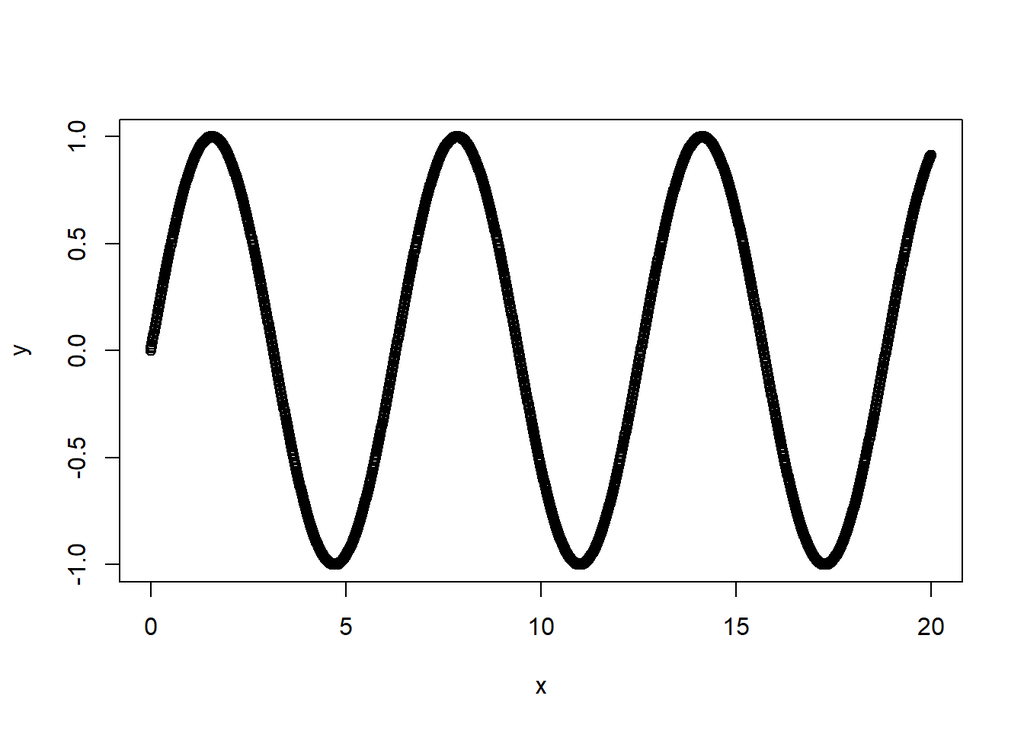

```r
plot(x,y)
```

Use the knit button to generate the HTML file corresponding to your R markdown notebook.

# 8 Replicability and reproducibility

Create a new section of your R markdown notebook with the heading " Replicability and reproducibility".

Within this section define the two concepts of “replicability” and “reproducibility”.

Replicability: Different experimenters will yield the same results from different data, when an experiment is repeated under similar conditions.

Reproducibility: Different scientists will yield the same results by repeating the analysis on the same data.

Which concept is stronger?

Replicability is the stronger concept as replicable research must also be reproducible.

Use the knit button to generate the HTML file corresponding to your R markdown notebook.